# **Analyse EDA des données de shopping des clients**

**Objectif du Projet :**

- L’objectif de ce projet est de réaliser une analyse exploratoire des données (EDA) sur un ensemble de données relatives aux habitudes de shopping des clients. L’analyse sera effectuée en utilisant le langage de programmation R, en mettant en œuvre des techniques de statistiques descriptives et des visualisations de données afin de comprendre les tendances et les comportements d’achat des clients.

**Présentation du Dataset :**

## Chargement des bibliothèques

```r
# Chargement des bibliothèques nécessaires
suppressWarnings({
library(ggplot2)
library(tidyverse)
library(lubridate)
library(data.table)
library(DescTools)
library(cluster)
library(GGally)
library(FactoMineR)
library(factoextra)
library(corrplot)
})
```

## Importation des données

```r
# Importer le dataset
df <- read.csv("C:/projetR/customer_shopping_data.csv")
```

## Exploration des données

```r
# Afficher les dimensions du dataset (nombre de lignes et de colonnes)
  dim(df)
```

```
## [1] 99457    10
```

- On a 99457 ligne et 10 colonnes

```r
# Afficher les premières lignes dataset
  head(df)
```

```
##   invoice_no customer_id gender age category quantity   price payment_method
## 1    I138884     C241288 Female  28 Clothing        5 1500.40    Credit Card
## 2    I317333     C111565   Male  21    Shoes        3 1800.51     Debit Card
## 3    I127801     C266599   Male  20 Clothing        1  300.08           Cash
## 4    I173702     C988172 Female  66    Shoes        5 3000.85    Credit Card
## 5    I337046     C189076 Female  53    Books        4   60.60           Cash
## 6    I227836     C657758 Female  28 Clothing        5 1500.40    Credit Card
##   invoice_date  shopping_mall
## 1     5/8/2022         Kanyon
## 2   12/12/2021 Forum Istanbul
## 3    9/11/2021      Metrocity
## 4   16/05/2021   Metropol AVM
## 5   24/10/2021         Kanyon
## 6   24/05/2022 Forum Istanbul
```

```r
# Afficher la structure du dataset pour comprendre les types de variables.
  str(df)
```

```
## 'data.frame':    99457 obs. of  10 variables:
##  $ invoice_no    : chr  "I138884" "I317333" "I127801" "I173702" ...
##  $ customer_id   : chr  "C241288" "C111565" "C266599" "C988172" ...
##  $ gender        : chr  "Female" "Male" "Male" "Female" ...
##  $ age           : int  28 21 20 66 53 28 49 32 69 60 ...
##  $ category      : chr  "Clothing" "Shoes" "Clothing" "Shoes" ...
##  $ quantity      : int  5 3 1 5 4 5 1 2 3 2 ...
##  $ price         : num  1500.4 1800.5 300.1 3000.8 60.6 ...
##  $ payment_method: chr  "Credit Card" "Debit Card" "Cash" "Credit Card" ...
##  $ invoice_date  : chr  "5/8/2022" "12/12/2021" "9/11/2021" "16/05/2021" ...
##  $ shopping_mall : chr  "Kanyon" "Forum Istanbul" "Metrocity" "Metropol AVM" ...
```

```r
# Afficher les noms des colonnes
  colnames(df)
```

```
##  [1] "invoice_no"     "customer_id"    "gender"         "age"
##  [5] "category"       "quantity"       "price"          "payment_method"
##  [9] "invoice_date"   "shopping_mall"
```

```r
# Résumer le dataset (statistiques descriptives)
  summary(df)
```

```
##   invoice_no        customer_id           gender               age
##  Length:99457       Length:99457       Length:99457       Min.   :18.00
##  Class :character   Class :character   Class :character   1st Qu.:30.00
##  Mode  :character   Mode  :character   Mode  :character   Median :43.00
##                                                           Mean   :43.43
##                                                           3rd Qu.:56.00
##                                                           Max.   :69.00
##    category            quantity         price         payment_method
##  Length:99457       Min.   :1.000   Min.   :   5.23   Length:99457
##  Class :character   1st Qu.:2.000   1st Qu.:  45.45   Class :character
##  Mode  :character   Median :3.000   Median : 203.30   Mode  :character
##                     Mean   :3.003   Mean   : 689.26
##                     3rd Qu.:4.000   3rd Qu.:1200.32
##                     Max.   :5.000   Max.   :5250.00
##  invoice_date       shopping_mall
##  Length:99457       Length:99457
##  Class :character   Class :character
##  Mode  :character   Mode  :character
##
##
##
```

1. **invoice_no**: Le numéro de facture
2. **customer_id**: Le numéro de client ,assigné de manière unique à chaque opération.
3. **gender**: Le genre du client, stocké sous forme de chaîne de caractères.
4. **age**: L’âge du client, stocké comme un entier positif.
5. **category**: La catégorie du produit acheté, stockée sous forme de chaîne de caractères.
6. **quantity**: La quantité de chaque produit par transaction, stockée comme un nombre.
7. **price**: Le prix unitaire du produit, stocké comme un nombre représentant le prix par unité en livres turques (TL).
8. **payment_method**: La méthode de paiement utilisée pour la transaction, stockée sous forme de chaîne de caractères.
9. **invoice_date**: La date de la facture, représentant le jour où la transaction a été générée.
10. **shopping_mall**: Le nom du centre commercial où la transaction a été effectuée, stocké sous forme de chaîne de caractères.

```r
# Vérifier s'il y a des doublons dans le DataFrame
doublons <- df[duplicated(df), ]

# Afficher les lignes dupliquées
print(doublons)
```

```
##  [1] invoice_no     customer_id    gender         age            category
##  [6] quantity       price          payment_method invoice_date   shopping_mall
## <0 rows> (or 0-length row.names)
```

- il n’y a pas des doublons dans le DataFrame

```r
# Calculer le nombre de valeurs manquantes par colonne
missing_values <- colSums(is.na(df))

# Afficher les colonnes avec des valeurs manquantes
print(missing_values)
```

```
##     invoice_no    customer_id         gender            age       category
##              0              0              0              0              0
##       quantity          price payment_method   invoice_date  shopping_mall
##              0              0              0              0              0
```

- le dataset ne contient aucune valeur manquante pour les variables que vous avez répertoriées. C’est une bonne nouvelle pour commencer !

## Nettoyage des données

```r
# converti la colonne invoice_date en format de date.
df <- df %>% mutate(invoice_date = as.Date(invoice_date,'%d/%m/%Y'))
```

- nous avons converti la colonne invoice_date en format de date.

```r
df <- df %>% mutate(total_sale = price*quantity)

df <- df %>% mutate(age_group = ifelse(age < 20, "10's",
                              ifelse(age < 30, "20's",
                              ifelse(age < 40, "30's",
                              ifelse(age < 50, "40's",
                              ifelse(age < 60, "50's", "60's")))))) %>%
  dplyr::select(shopping_mall, invoice_date, invoice_no, customer_id, gender, age, age_group, category, quantity, price, total_sale,
         payment_method)
head(df)
```

```
##    shopping_mall invoice_date invoice_no customer_id gender age age_group
## 1         Kanyon   2022-08-05    I138884     C241288 Female  28      20's
## 2 Forum Istanbul   2021-12-12    I317333     C111565   Male  21      20's
## 3      Metrocity   2021-11-09    I127801     C266599   Male  20      20's
## 4   Metropol AVM   2021-05-16    I173702     C988172 Female  66      60's
## 5         Kanyon   2021-10-24    I337046     C189076 Female  53      50's
## 6 Forum Istanbul   2022-05-24    I227836     C657758 Female  28      20's
##   category quantity   price total_sale payment_method
## 1 Clothing        5 1500.40    7502.00    Credit Card
## 2    Shoes        3 1800.51    5401.53     Debit Card
## 3 Clothing        1  300.08     300.08           Cash
## 4    Shoes        5 3000.85   15004.25    Credit Card
## 5    Books        4   60.60     242.40           Cash
## 6 Clothing        5 1500.40    7502.00    Credit Card
```

- Nous avons extrait certaines colonnes de notre DataFrame et nous avons créé de nouvelles colonnes telles que `total_sale` et `age_group`.

## Analyse exploratoire des données (EDA)

### Présicer les niveaux de chaque variable

```r
sapply(df[, c("shopping_mall", "gender", "category", "payment_method", "age_group")], function(x) length(unique(x)))
```

```
##  shopping_mall         gender       category payment_method      age_group
##             10              2              8              3              6
```

```r
#les niveaux de chaque variable

lapply(df[, c("shopping_mall", "gender", "category", "payment_method", "age_group")], unique)
```

```
## $shopping_mall
##  [1] "Kanyon"            "Forum Istanbul"    "Metrocity"
##  [4] "Metropol AVM"      "Istinye Park"      "Mall of Istanbul"
##  [7] "Emaar Square Mall" "Cevahir AVM"       "Viaport Outlet"
## [10] "Zorlu Center"
##
## $gender
## [1] "Female" "Male"
##
## $category
## [1] "Clothing"        "Shoes"           "Books"           "Cosmetics"
## [5] "Food & Beverage" "Toys"            "Technology"      "Souvenir"
##
## $payment_method
## [1] "Credit Card" "Debit Card"  "Cash"
##
## $age_group
## [1] "20's" "60's" "50's" "40's" "30's" "10's"
```

```r
summary(df)
```

```
##  shopping_mall       invoice_date         invoice_no        customer_id
##  Length:99457       Min.   :2021-01-01   Length:99457       Length:99457
##  Class :character   1st Qu.:2021-07-19   Class :character   Class :character
##  Mode  :character   Median :2022-02-05   Mode  :character   Mode  :character
##                     Mean   :2022-02-04
##                     3rd Qu.:2022-08-22
##                     Max.   :2023-03-08
##     gender               age         age_group           category
##  Length:99457       Min.   :18.00   Length:99457       Length:99457
##  Class :character   1st Qu.:30.00   Class :character   Class :character
##  Mode  :character   Median :43.00   Mode  :character   Mode  :character
##                     Mean   :43.43
##                     3rd Qu.:56.00
##                     Max.   :69.00
##     quantity         price           total_sale       payment_method
##  Min.   :1.000   Min.   :   5.23   Min.   :    5.23   Length:99457
##  1st Qu.:2.000   1st Qu.:  45.45   1st Qu.:  136.35   Class :character
##  Median :3.000   Median : 203.30   Median :  600.17   Mode  :character
##  Mean   :3.003   Mean   : 689.26   Mean   : 2528.79
##  3rd Qu.:4.000   3rd Qu.:1200.32   3rd Qu.: 2700.72
##  Max.   :5.000   Max.   :5250.00   Max.   :26250.00
```

### Effectué une analyse univariée en examinant la distribution des variables numériques

```r
summary(df[, c("age", "quantity", "price")])
```

```
##       age           quantity         price
##  Min.   :18.00   Min.   :1.000   Min.   :   5.23
##  1st Qu.:30.00   1st Qu.:2.000   1st Qu.:  45.45
##  Median :43.00   Median :3.000   Median : 203.30
##  Mean   :43.43   Mean   :3.003   Mean   : 689.26
##  3rd Qu.:56.00   3rd Qu.:4.000   3rd Qu.:1200.32
##  Max.   :69.00   Max.   :5.000   Max.   :5250.00
```

- **Pour l’âge (age)**, la valeur minimale est 18 ans, la médiane (50e percentile) est de 43 ans, et la valeur maximale est 69 ans. La moyenne d’âge est d’environ 43 ans.
- **Pour la quantité (quantity)**, la valeur minimale est 1, le 1er quartile (25e percentile) est de 2, la médiane est de 3, le 3e quartile (75e percentile) est de 4, et la valeur maximale est 5. La moyenne de la quantité est d’environ 3,003.
- **Pour le prix (price)**, le prix minimum est de 5,23, le 1er quartile est de 45,45, la médiane est de 203,30, le 3e quartile est de 1200,32, et le prix maximum est de 5250,00. La moyenne des prix est d’environ 689,26.

```r
# Calcul de l'étendue des prix
price_range <- range(df$price, na.rm = TRUE)
price_range_diff <- price_range[2] - price_range[1]

cat("Price range: ", price_range[1], " - ", price_range[2], "\n")
```

```
## Price range:  5.23  -  5250
```

```r
cat("Price range difference: ", price_range_diff, "\n")
```

```
## Price range difference:  5244.77
```

- les prix varient de 5.23 à 5250, avec une différence totale de 5244.77 entre le prix le plus bas et le prix le plus élevé. Cela signifie qu’il y a une grande variabilité dans les prix des produits

```r
price_sd <- sd(df$price, na.rm = TRUE)
cat("Price standard deviation: ", price_sd, "\n")
```

```
## Price standard deviation:  941.1846
```

```r
price_var <- var(df$price, na.rm = TRUE)
cat("Price variance: ", price_var, "\n")
```

```
## Price variance:  885828.4
```

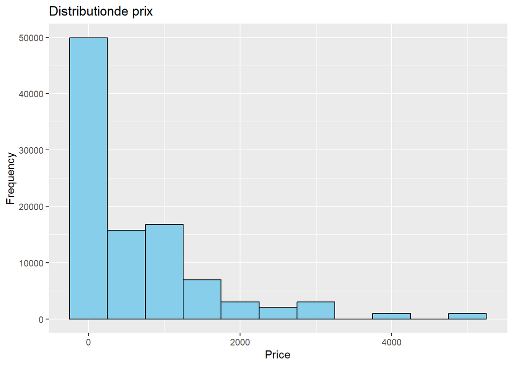

```r
ggplot(df, aes(x = price)) +
  geom_histogram(binwidth = 500, fill = "skyblue", color = "black") +
  ggtitle("Distributionde prix") +
  xlab("Price") +
  ylab("Frequency")
```

## Data Visualisation :

```r
# Compter le nombre de valeurs pour chaque catégorie de genre
table(df$gender)
```

```
##
## Female   Male
##  59482  39975
```

```r
# Calculer le montant total dépensé par les hommes
males_total_money <- sum(df[df$gender == 'Male', 'price'])

# Calculer le montant total dépensé par les femmes
females_total_money <- sum(df[df$gender == 'Female', 'price'])

# Afficher les montants totaux dépensés par les hommes et les femmes
print(paste("Total money spent by males:", males_total_money))
```

```
## [1] "Total money spent by males: 27619564.29"
```

```r
print(paste("Total money spent by females:", females_total_money))
```

```
## [1] "Total money spent by females: 40931801.62"
```

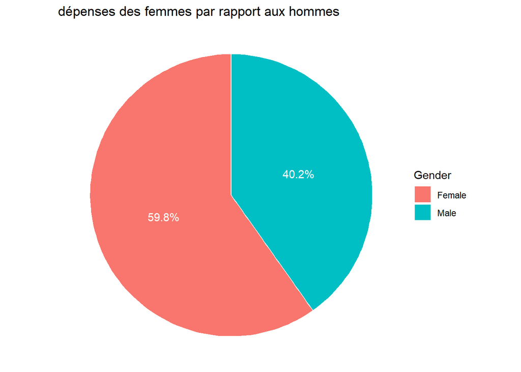

```r
table1 <- df %>%
  count(gender) %>%
  mutate(percentage = n / sum(n) * 100)

ggplot(table1, aes(x = "", y = percentage, fill = gender)) +
  geom_bar(stat = "identity", width = 1, color = "white") +
  coord_polar("y", start = 0) +
  geom_text(aes(label = paste0(round(percentage, 1), "%")), position = position_stack(vjust = 0.5), color = "white") +
  ggtitle(" dépenses des femmes par rapport aux hommes") + labs(fill= "Gender") +
  theme_void()
```

- Les femmes à Istanbul ont une tendance d’achat plus forte que les hommes. Cela peut provenir des jeunes célibataires et des femmes mariées qui font des achats pour l’ensemble du foyer.

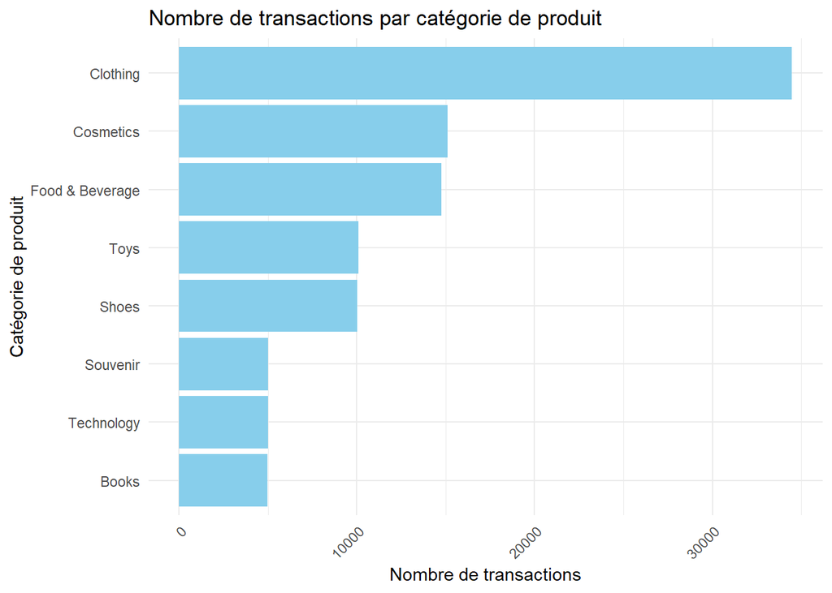

```r
# Calculer le nombre de transactions par catégorie
transactions_by_category <- df %>%
  group_by(category) %>%
  summarise(total_transactions = n()) %>%
  arrange(desc(total_transactions))

ggplot(transactions_by_category, aes(x = reorder(category, total_transactions), y = total_transactions)) +
  geom_bar(stat = "identity", fill = "skyblue") +
  labs(title = "Nombre de transactions par catégorie de produit",
       x = "Catégorie de produit",
       y = "Nombre de transactions") +
  theme_minimal() +
  theme(axis.text.x = element_text(angle = 45, hjust = 1)) +
  coord_flip()
```

```r
# Compter le nombre de transactions par catégorie et par sexe
transactions_by_category_gender <- df %>%
  group_by(category, gender) %>%
  summarise(total_transactions = n())
```

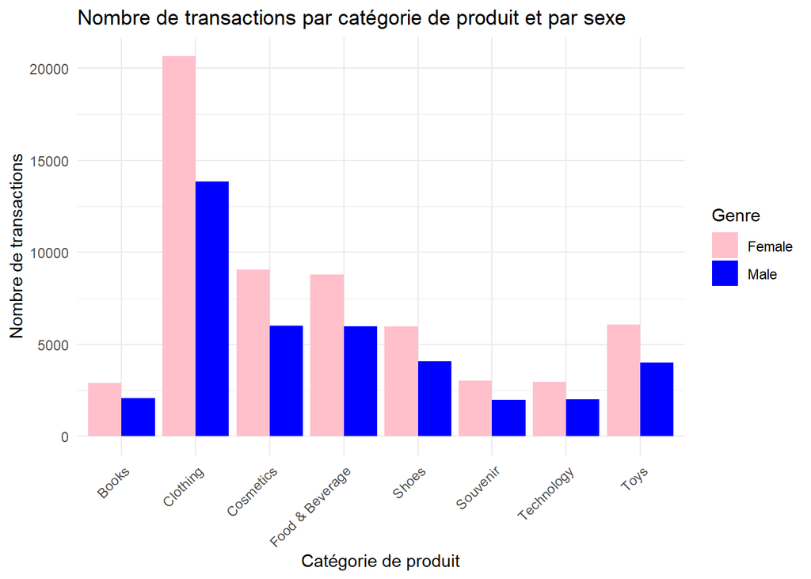

```r
# Créer le graphique à barres groupé
ggplot(transactions_by_category_gender, aes(x = category, y = total_transactions, fill = gender)) +
  geom_bar(stat = "identity", position = "dodge") +
  labs(title = "Nombre de transactions par catégorie de produit et par sexe",
       x = "Catégorie de produit",
       y = "Nombre de transactions",
       fill = "Genre") +
  theme_minimal() +
  theme(axis.text.x = element_text(angle = 45, hjust = 1)) +
  scale_fill_manual(values = c("pink", "blue"))
```

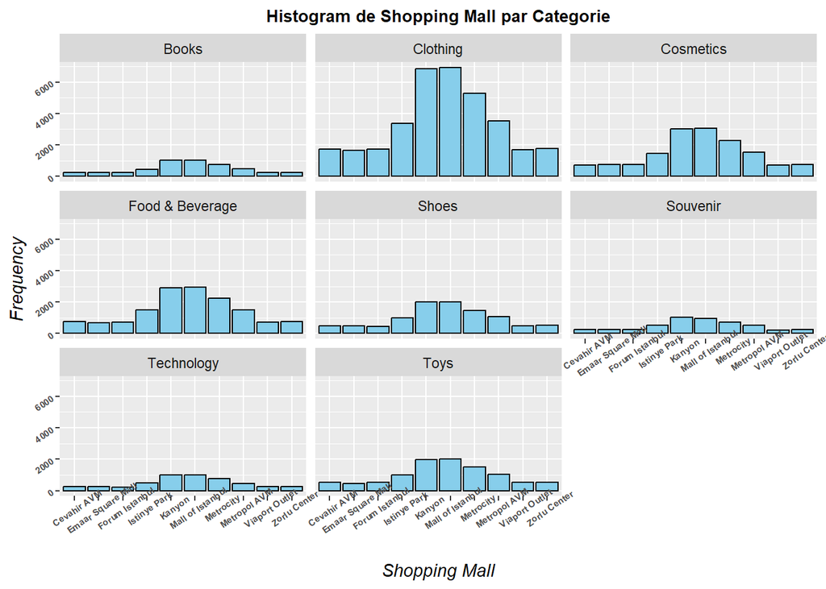

```r
df %>% ggplot(data = df, mapping = aes(x = shopping_mall)) +
  geom_histogram(binwidth = 8, fill = 'skyblue', col = 'black', stat = "count") + facet_wrap(~ category) +
  xlab("Shopping Mall") +
  ylab("Frequency") +
  ggtitle("Histogram de Shopping Mall par Categorie") +
  theme(plot.title = element_text(face = 'bold', size = 10, hjust = .5),
        axis.title = element_text(face = 'italic'),
        axis.text = element_text(face = 'bold', size = 5.5, angle = 35))
```

- Les centres commerciaux les plus fréquentés sont le Mall of Istanbul et Kanyon, situés au centre de la Turquie. De plus, les vêtements sont la catégorie la plus vendue, suivie par les cosmétiques et l’alimentation et les boissons, qui sont toutes influencées par de grandes marques de mode présentées au Mall of Istanbul et à Kanyon. En dehors de cette analyse, dans l’ensemble, le schéma de distribution des centres commerciaux entre les catégories est presque le même.

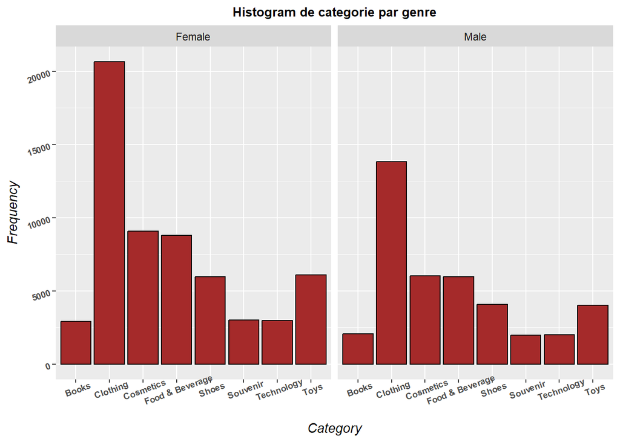

```r
df %>% ggplot(data = df, mapping = aes(x = category)) +
  geom_histogram(binwidth = 5, fill = 'brown', col = 'black', stat = "count") + facet_wrap(~ gender) +
  xlab("Category") +
  ylab("Frequency") +
  ggtitle("Histogram de categorie par genre") +
  theme(plot.title = element_text(face = 'bold', size = 10, hjust = .5),
        axis.title = element_text(face = 'italic'),
        axis.text = element_text(face = 'bold', size = 7, angle = 20))
```

- Les femmes sont le genre qui fait le plus souvent des achats par rapport aux hommes. De plus, de manière similaire au premier histogramme, les vêtements sont la catégorie la plus vendue, suivis par les cosmétiques et l’alimentation et les boissons, ce qui permet de prédire que les jeunes mamans devraient constituer le segment principal. En dehors de cette analyse, dans l’ensemble, le schéma de distribution des genres entre les catégories est presque le même.

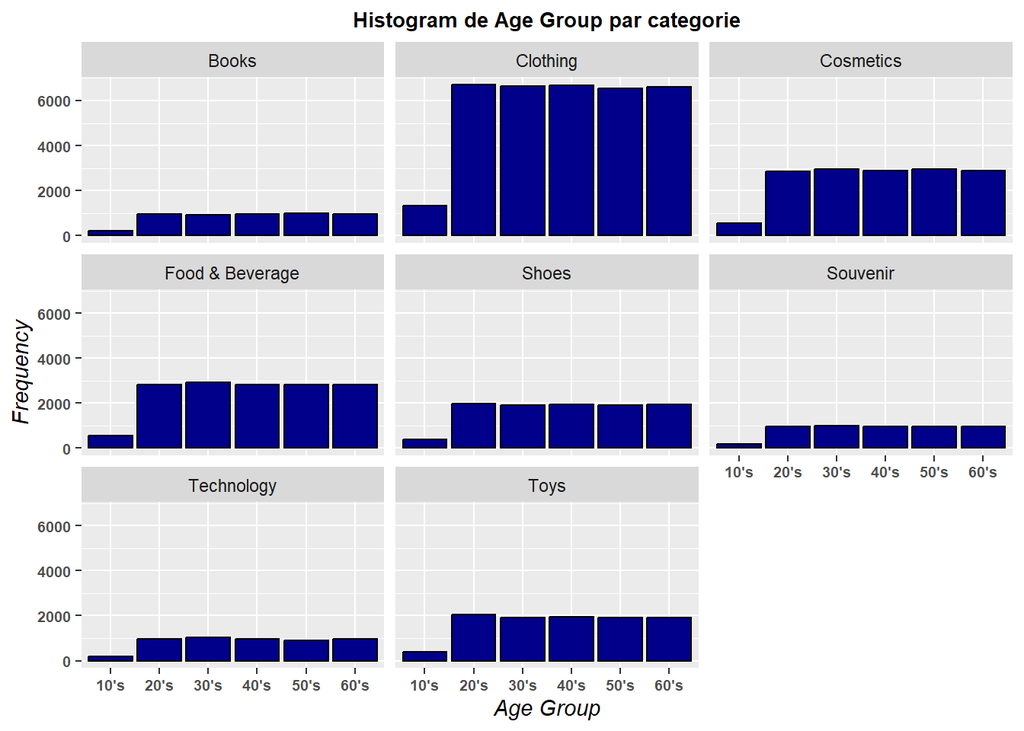

```r
df %>% ggplot(data = df, mapping = aes(x = age_group)) +
  geom_histogram(binwidth = 5, fill = 'darkblue', col = 'black', stat = "count") + facet_wrap(~ category) +
  xlab("Age Group") +
  ylab("Frequency") +
  ggtitle("Histogram de Age Group par categorie") +
  theme(plot.title = element_text(face = 'bold', size = 10, hjust = .5),
        axis.title = element_text(face = 'italic'),
        axis.text = element_text(face = 'bold', size = 7, angle = 0))
```

- Le schéma de distribution des groupes d’âge entre les catégories est presque similaire. En même temps, le groupe d’âge des 10 ans (moins de 20 ans) achète des vêtements et des cosmétiques plus fréquemment que les autres catégories ; le groupe d’âge des 20 ans (entre 20 et 30 ans) a tendance à acheter des jouets plus que les différents groupes d’âge, ce qui indique que ce groupe a plus de jeunes enfants que les autres.

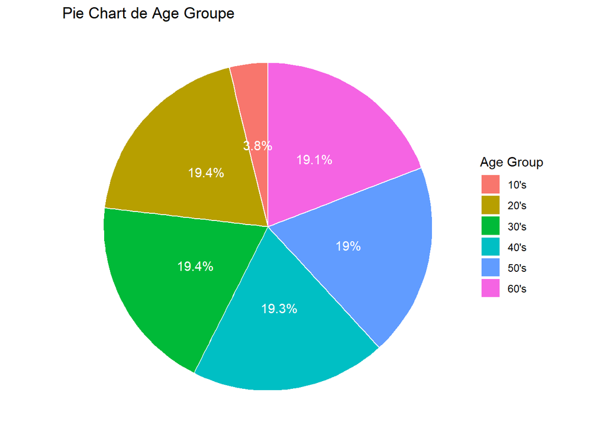

```r
frequency_table2 <- df %>%
  count(age_group) %>%
  mutate(percentage = n / sum(n) * 100)

ggplot(frequency_table2, aes(x = "", y = percentage, fill = age_group)) +
  geom_bar(stat = "identity", width = 1, color = "white") +
  coord_polar("y", start = 0) +
  geom_text(aes(label = paste0(round(percentage, 1), "%")), position = position_stack(vjust = 0.5), color = "white") +
  ggtitle("Pie Chart de Age Groupe") + labs(fill= "Age Group") +
  theme_void()
```

- À l’exception du segment « 10s » (âge inférieur à 20 ans), chaque groupe d’âge partageait presque la même proportion avec 19% par segment. Cependant, le segment des « 20s » jusqu’aux « 30s », soit les clients âgés de 20 à 40 ans, avait légèrement plus de pourcentage (19,4% chacun), ce qui indique qu’ils sont les principaux clients des centres commerciaux.

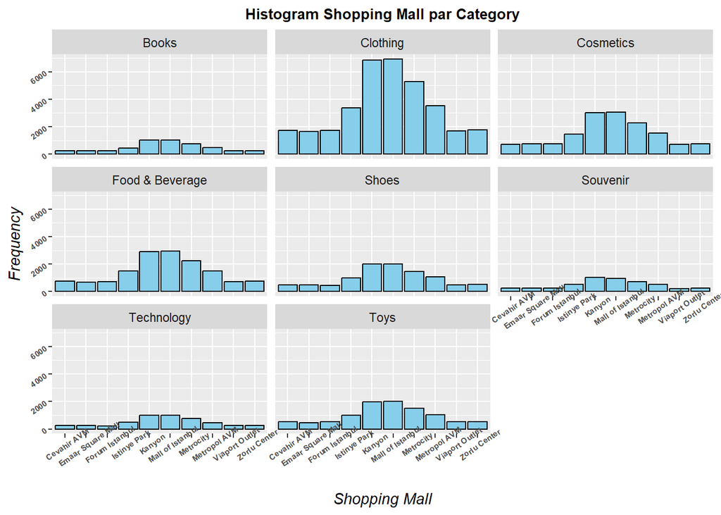

```r
options(repr.plot.height = 8, repr.plot.width = 10)

df %>% ggplot(data = df, mapping = aes(x = shopping_mall)) +
  geom_histogram(binwidth = 8, fill = 'skyblue', col = 'black', stat = "count") + facet_wrap(~ category) +
  xlab("Shopping Mall") +
  ylab("Frequency") +
  ggtitle("Histogram Shopping Mall par Category") +
  theme(plot.title = element_text(face = 'bold', size = 10, hjust = .5),
        axis.title = element_text(face = 'italic'),
        axis.text = element_text(face = 'bold', size = 5.5, angle = 35))
```

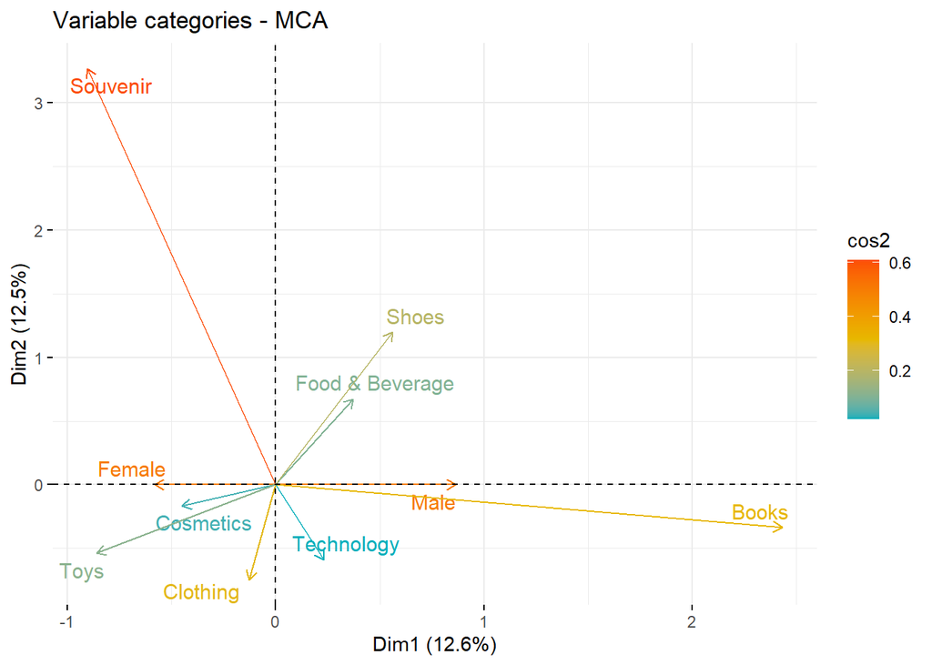

```r
# Sélectionner les variables pertinentes
selected_cols <- c("gender", "category")

# Filtrer les données
data_filtered <- df[, selected_cols]
pca_result <- MCA(data_filtered, graph = FALSE)

# Visualiser le cercle de corrélation
fviz_pca_var(pca_result, col.var = "cos2", gradient.cols = c("#00AFBB", "#E7B800", "#FC4E07"), repel = TRUE)
```

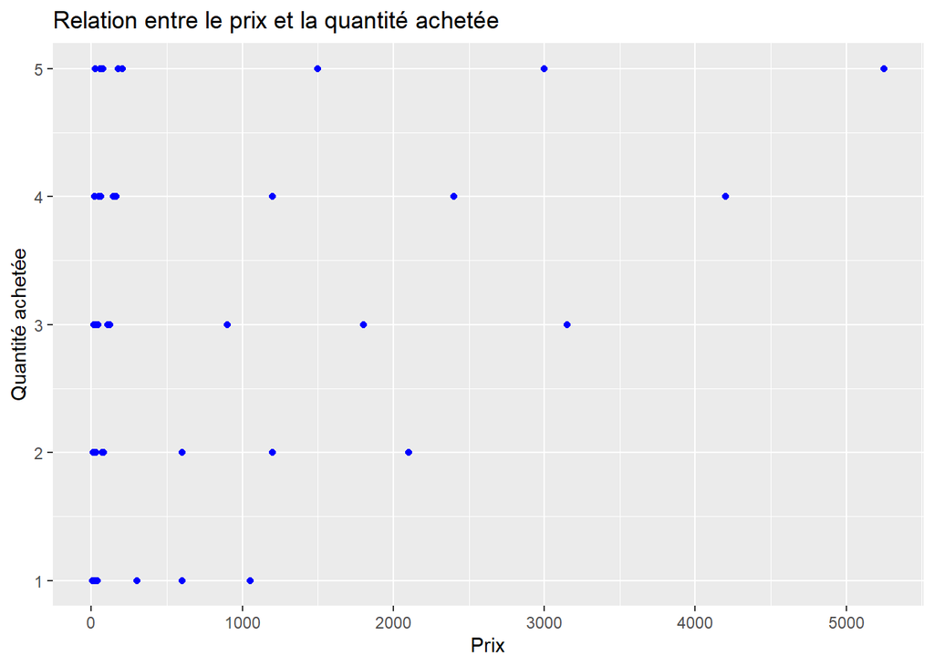

```r
# Créer un nuage de points pour la relation entre le prix et la quantité achetée
ggplot(data = df, aes(x = price, y = quantity)) +
  geom_point(color = "blue", alpha = 0.5) +
  labs(title = "Relation entre le prix et la quantité achetée",
       x = "Prix",
       y = "Quantité achetée")
```

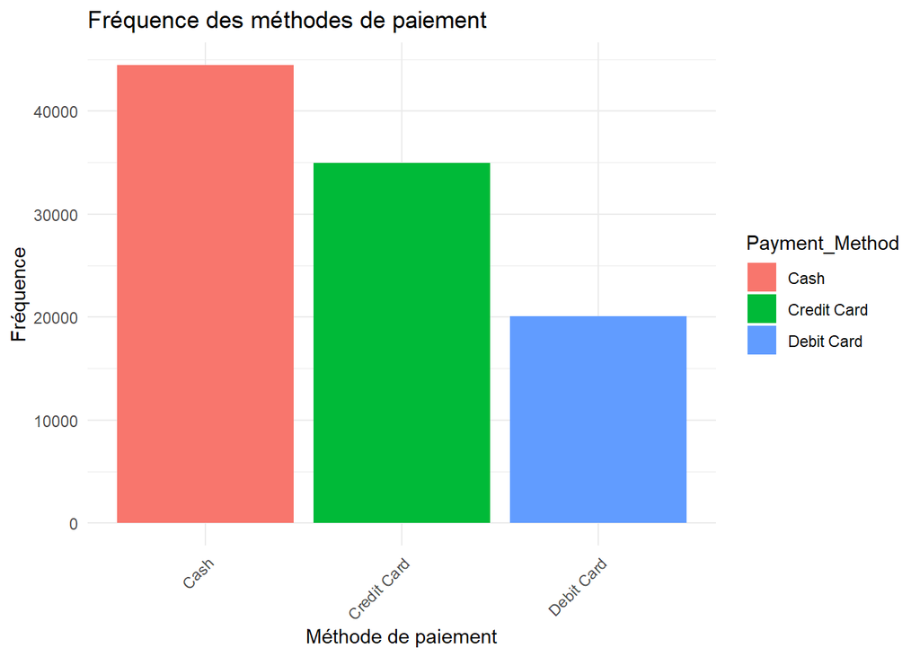

```r
# Calculer la fréquence des méthodes de paiement
payment_frequency <- table(df$payment_method)

# Convertir en data frame pour la visualisation
payment_df <- as.data.frame(payment_frequency)
payment_df$Payment_Method <- rownames(payment_df)
colnames(payment_df) <- c("Payment_Method", "Frequency")

# Créer un diagramme à barres
ggplot(payment_df, aes(x = Payment_Method, y = Frequency, fill = Payment_Method)) +
  geom_bar(stat = "identity") +
  labs(title = "Fréquence des méthodes de paiement",
       x = "Méthode de paiement",
       y = "Fréquence") +
  theme_minimal() +
  theme(axis.text.x = element_text(angle = 45, hjust = 1))
```

- Le paiement en espèces reste la méthode de paiement principale.

## Régression

### **Hypothèse 1 : L’âge et le genre impactent le comportement d’achat**

```r
shopping_model1 <- lm(quantity ~ age + gender, data =df)
summary(shopping_model1)
```

```
##
## Call:
## lm(formula = quantity ~ age + gender, data = df)
##
## Residuals:
##      Min       1Q   Median       3Q      Max
## -2.00519 -1.00424 -0.00343  0.99739  1.99839
##
## Coefficients:
##               Estimate Std. Error t value Pr(>|t|)
## (Intercept)  3.001e+00  1.422e-02 210.998   <2e-16 ***
## age          6.281e-05  2.989e-04   0.210    0.834
## genderMale  -3.748e-04  9.139e-03  -0.041    0.967
## ---
## Signif. codes:  0 '***' 0.001 '**' 0.01 '*' 0.05 '.' 0.1 ' ' 1
##
## Residual standard error: 1.413 on 99454 degrees of freedom
## Multiple R-squared:  4.613e-07,  Adjusted R-squared:  -1.965e-05
## F-statistic: 0.02294 on 2 and 99454 DF,  p-value: 0.9773
```

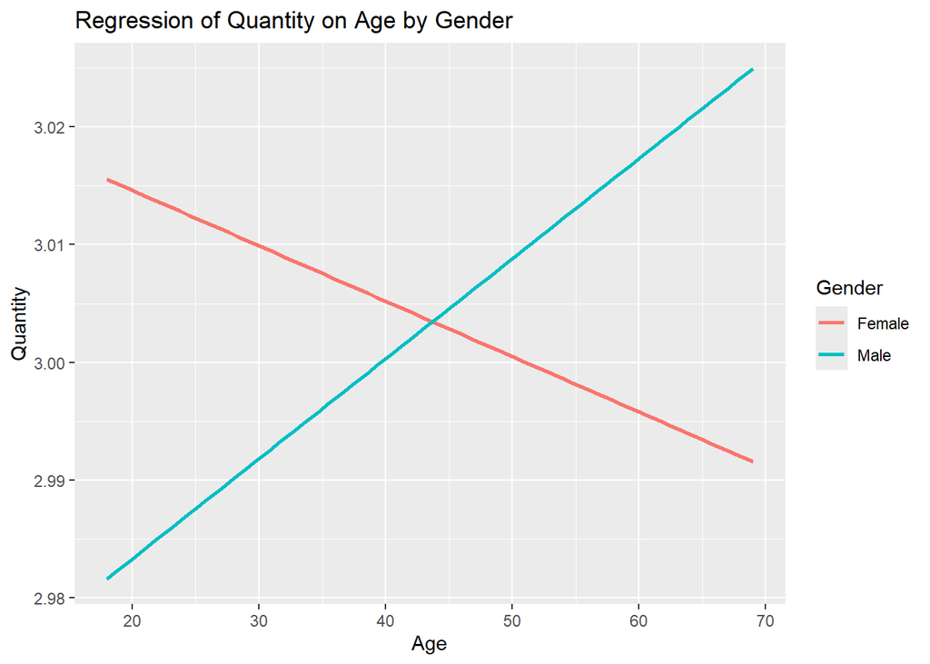

```r
ggplot(data = df, aes(x = age, y = quantity, color = gender)) +
  geom_smooth(method = "lm", se = FALSE) +  # Add a linear regression line
  labs(x = "Age", y = "Quantity", title = "Regression of Quantity on Age by Gender") + guides(color = guide_legend(title = "Gender"))
```

- Analyse graphique : La quantité achetée semble augmenter avec l’âge pour les hommes et diminuer pour les femmes.
- Inférence : L’analyse de régression ne montre aucune relation significative entre l’âge, le genre et la quantité d’achats. Ni l’âge ni le genre ne semblent avoir un impact statistiquement significatif sur le comportement d’achat dans ce jeu de données.

### **Hypothèse 2 : La méthode de paiement affecte le montant des achats**

```r
shopping_model2 <- lm(price ~ payment_method, data = df)
summary(shopping_model2)
```

```
##
## Call:
## lm(formula = price ~ payment_method, data = df)
##
## Residuals:
##    Min     1Q Median     3Q    Max
## -685.6 -645.4 -483.7  509.5 4563.0
##
## Coefficients:
##                           Estimate Std. Error t value Pr(>|t|)
## (Intercept)                690.823      4.464 154.743   <2e-16 ***
## payment_methodCredit Card   -2.281      6.730  -0.339    0.735
## payment_methodDebit Card    -3.794      8.003  -0.474    0.635
## ---
## Signif. codes:  0 '***' 0.001 '**' 0.01 '*' 0.05 '.' 0.1 ' ' 1
##
## Residual standard error: 941.2 on 99454 degrees of freedom
## Multiple R-squared:  2.572e-06,  Adjusted R-squared:  -1.754e-05
## F-statistic: 0.1279 on 2 and 99454 DF,  p-value: 0.88
```

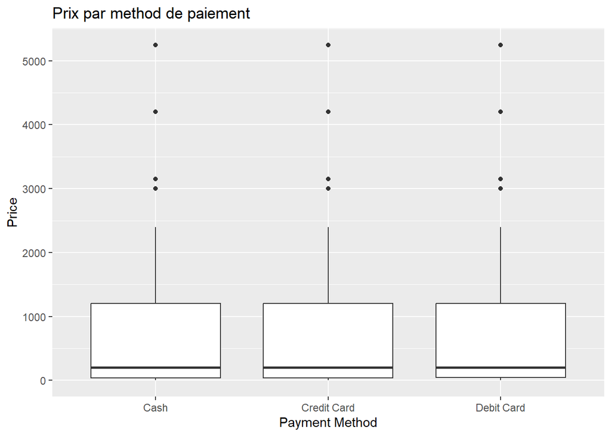

```r
ggplot(data = df, aes(x = payment_method, y = price)) +
  geom_boxplot() +
  labs(x = "Payment Method", y = "Price", title = "Prix par method de paiement")
```

- Analyse graphique : Le mode de paiement (carte de crédit ou carte de débit) n’a pas d’impact significatif sur le montant des achats dans ce jeu de données, car il n’est pas un prédicteur statistiquement significatif.
- De la même manière, en analysant, nous pouvons conclure que le mode de paiement (carte de crédit ou carte de débit) n’a pas d’impact significatif sur le montant des achats dans ce jeu de données, car il n’est pas un prédicteur statistiquement significatif.

### **Hypothèse 3 : L’emplacement du centre commercial influence la fréquence d’achat**

```r
shopping_model3 <- lm(quantity ~ shopping_mall, data = df)
summary(shopping_model3)
```

```
##
## Call:
## lm(formula = quantity ~ shopping_mall, data = df)
##
## Residuals:
##      Min       1Q   Median       3Q      Max
## -2.01429 -1.01247 -0.00177  1.00481  2.00926
##
## Coefficients:
##                                  Estimate Std. Error t value Pr(>|t|)
## (Intercept)                     2.9951913  0.0200017 149.747   <2e-16 ***
## shopping_mallEmaar Square Mall  0.0189429  0.0285501   0.663    0.507
## shopping_mallForum Istanbul     0.0070322  0.0283496   0.248    0.804
## shopping_mallIstinye Park       0.0172818  0.0245808   0.703    0.482
## shopping_mallKanyon             0.0042033  0.0223785   0.188    0.851
## shopping_mallMall of Istanbul   0.0190994  0.0223650   0.854    0.393
## shopping_mallMetrocity         -0.0044512  0.0230887  -0.193    0.847
## shopping_mallMetropol AVM       0.0094342  0.0244250   0.386    0.699
## shopping_mallViaport Outlet    -0.0004823  0.0283973  -0.017    0.986
## shopping_mallZorlu Center       0.0065821  0.0281694   0.234    0.815
## ---
## Signif. codes:  0 '***' 0.001 '**' 0.01 '*' 0.05 '.' 0.1 ' ' 1
##
## Residual standard error: 1.413 on 99447 degrees of freedom
## Multiple R-squared:  3.622e-05,  Adjusted R-squared:  -5.428e-05
## F-statistic: 0.4002 on 9 and 99447 DF,  p-value: 0.9356
```

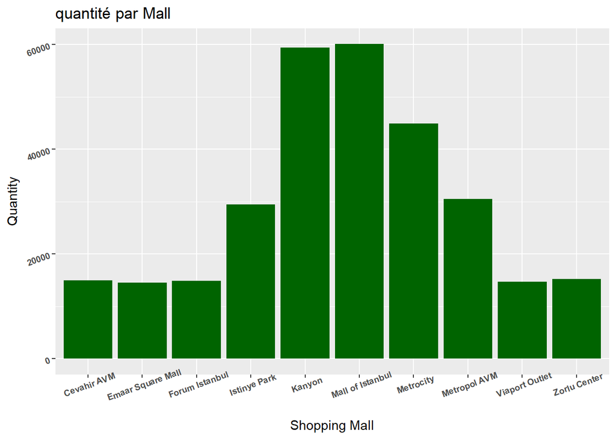

```r
ggplot() +
  geom_col(data = df, aes(x = shopping_mall, y = quantity), fill = 'darkgreen') +
  labs(x = "Shopping Mall", y = "Quantity", title = "quantité par Mall") +
  theme(axis.text = element_text(face = 'bold', size = 7, angle = 20))
```

### **Hypothèse 4 : La catégorie de produit affecte le montant des achats**

```r
shopping_model4 <- lm(price ~ category, data = df)
summary(shopping_model4)
```

```
##
## Call:
## lm(formula = price ~ category, data = df)
##
## Residuals:
##      Min       1Q   Median       3Q      Max
## -2106.94   -41.13    -0.47    40.19  2093.06
##
## Coefficients:
##                         Estimate Std. Error t value Pr(>|t|)
## (Intercept)               45.569      7.021   6.491 8.59e-11 ***
## categoryClothing         855.515      7.511 113.908  < 2e-16 ***
## categoryCosmetics         76.880      8.096   9.496  < 2e-16 ***
## categoryFood & Beverage  -29.897      8.118  -3.683 0.000231 ***
## categoryShoes           1761.820      8.588 205.142  < 2e-16 ***
## categorySouvenir         -10.674      9.920  -1.076 0.281905
## categoryTechnology      3111.367      9.921 313.604  < 2e-16 ***
## categoryToys              62.165      8.581   7.245 4.37e-13 ***
## ---
## Signif. codes:  0 '***' 0.001 '**' 0.01 '*' 0.05 '.' 0.1 ' ' 1
##
## Residual standard error: 495.5 on 99449 degrees of freedom
## Multiple R-squared:  0.7229, Adjusted R-squared:  0.7228
## F-statistic: 3.706e+04 on 7 and 99449 DF,  p-value: < 2.2e-16
```

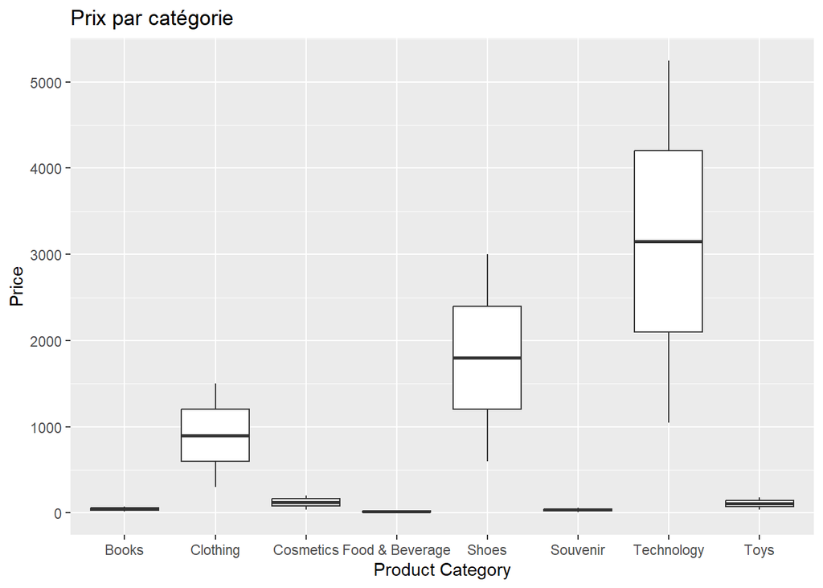

```r
ggplot(df, aes(x = category, y = price)) +
  geom_boxplot() +
  labs(x = "Product Category", y = "Price") +
  ggtitle("Prix par catégorie")
```

- Analyse graphique : Dans l’ensemble, le diagramme en boîte confirme l’hypothèse selon laquelle la catégorie de produit affecte le montant des achats, les produits technologiques ayant le plus d’impact, suivis des chaussures et des vêtements.
- De la même manière, les résultats suggèrent que la catégorie de produit affecte significativement le montant des achats, les produits technologiques ayant le plus d’impact, suivis des chaussures et des vêtements. En même temps, l’alimentation et les boissons peuvent nuire au montant des achats. Sur la base des résultats, la catégorie souvenir pourrait ne pas affecter significativement le montant des achats.